# TP1

Amine Zarbi / Siham Tassouli / Wafae Hatifi

March 4, 2019

## 1) Données simulées et p-valeurs

## Question a:

On commence par mettre le seed à 0. On simule 6000 variables aléatoires de dimension 201. Chaque variable aléatoire comporte 201 composantes aléatoires indépendantes, centrées et de variance égale à 1.

On stocke le tout dans une matrice et puis dans une dataframe.

## Question b:

## Modèle de régression linéaire:

Si on note $M$ la dataframe obtenue par la simulation de ces 6000 variables aléatoires, et conformément aux notations de l’énoncé, on peut écrire $M$ sous la forme :

$M = (V_{1} \dots V_{201})$

Où $V_{1} \dots V_{201}$ les variables colonnes de taille 6000.

Le but de ce modèle est d’estimer la première variable $V_{1}$ en utilisant les 200 autres variables.

On note ainsi $X$ la matrice extraite augmentée du vecteur unité, égale à $(1_{6000},V_{2}, \dots, V_{201})$ et on utilise l’équation matricielle de la régression linéaire :

$V_{1} = X\beta + \epsilon$

où $\beta$ est le vecteur des coefficients de la régression et $\epsilon$ le vecteur des résidus centrés.

## Le vrai modèle de la régréssion :

Le fait de simuler les 201 composantes de chaque variable aléatoire à l’aide de rnorm (de façon aléatoire) insinue une indépendance entre toutes ces composantes, et par la suite une indépendance entre les variables (colonnes). On peut donc affirmer qu’il n’y pas de corrélation entre la 1ère variable $V_{1}$ et les autres 200 variables.

Ainsi, si on utilise la formule de la régréssion linéaire, on a forcément le vecteur $\beta$ des coefficients qui est égal au vecteur null. L’équation de la régression devient alors sous la forme :

$V_{1} = \epsilon$ avec $\sigma = 1$

## Différence entre les deux modèles :

Le premier modèle naĩf, utilisé par R, ne tient pas compte de l’indépendance des 201 variables et estime dès lors les coefficients de régression, alors que le vrai modèle de la régression sait dèja qu’il ya indépendance et que les 200 autres variables n’ont aucun impact dans l’estimation de la première variable.

# Question c:

On utilise la commande “lm” de la régression linéaire en posant les bons arguments:

Vu la longeur du summary de la régression, Veuillez trouver ci-dessous les résulats concenant le coefficient de corrélation du modèle:

Residual standard error: 1.002 on 5799 degrees of freedom Multiple R-squared: 0.03717, Adjusted R-squared: 0.003964 F-statistic: 1.119 on 200 and 5799 DF, p-value: 0.1231

On calcule le nombre de coefficients du vecteur $\beta$ supposés non nuls au seuil 5%

5% correspondant à la probabilité de rejeter à tort l’hypothèse nulle “$\beta_{i} = 0$”, ce qui est équivalent à affirmer que le coeffcient $\beta_{i}$ est non null.

On trouve qu’au seuil de 5%, le nombre de coefficients non nuls est égal à 11.

On remarque alors qu’au seuil de 5%, la proportion des coefficients non nuls est égale à $\frac{11}{200}$ qui est à peu prés égale à 5%. Ce résultat est donc cohérent puisque la proportion est une bonne estimation de la probabilité.

Le nombre des coefficients non nuls obtenu est sensible au seuil fixé, plus le seuil augmente, plus la probabilité d’affirmer à tort que les coefficients sont non nuls est grande. Or, dans ce modèle, le nombre des coefficients non nuls doit être égal à 0, ce qui pose problème !

## 2) Prédicteurs corrélés et intervalles de confiance :

## Question a)

On simule le modèle de taille 1000 et on dessine le nuage des points $(X_{1}, X_{2})$

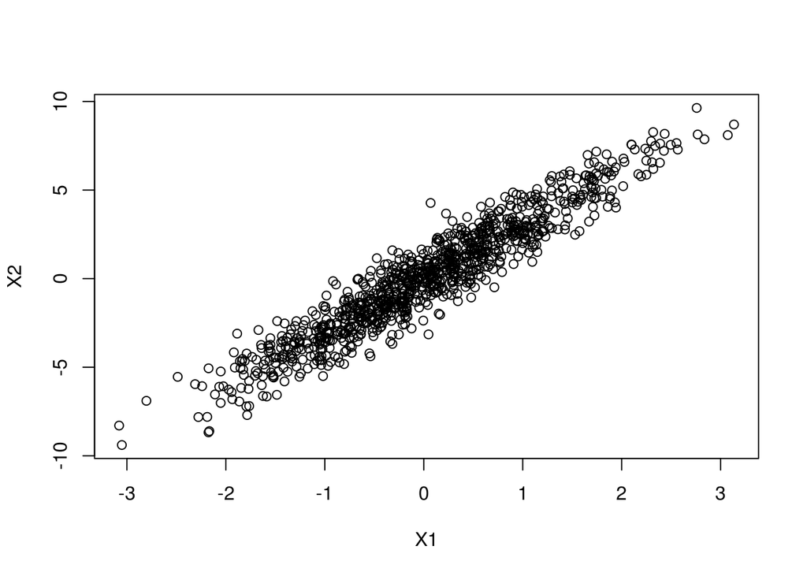

On remarque que le nuage prend la forme d’une fonction presque linéaire, ce qui cohérent avec la 2ème formule du modèle comportant un bruit centré réduit.

## Question b:

On met le seed à 3 et on fixe $n$ à 10, on simule à nouveau le modèle

```
##  [1] -3.170999 -1.243622  2.115066 -4.022350  2.450722  1.071767  2.549269
##  [8]  6.830265 -1.723195  6.132504
```

## Modèle 1:

On simule le premier modèle $Y$~$X_{1}$:

```
##
## Call:
## lm(formula = Yp ~ Xp1)
##
## Residuals:
##     Min      1Q  Median      3Q     Max
## -1.4216 -0.5664 -0.3675  0.6896  1.8840
##
## Coefficients:
##             Estimate Std. Error t value Pr(>|t|)
## (Intercept)   1.3733     0.3258   4.215  0.00294 **
## Xp1           4.0861     0.3954  10.334 6.64e-06 ***
## ---
## Signif. codes:  0 '***' 0.001 '**' 0.01 '*' 0.05 '.' 0.1 ' ' 1
##
## Residual standard error: 1.027 on 8 degrees of freedom
## Multiple R-squared:  0.9303, Adjusted R-squared:  0.9216
## F-statistic: 106.8 on 1 and 8 DF,  p-value: 6.637e-06
```

```
##          1          2          3          4          5          6
## -2.5573228  0.1779683  2.4307123 -3.3344997  2.1732637  1.4963589
##          7          8          9         10
##  1.7222968  5.9358900 -3.6071494  6.5519098
```

## Modèle 2:

On simule le deuxième modèle $Y$~$X_{2}$:

```
##
## Call:
## lm(formula = Yp ~ Xp2)
##
## Residuals:
##     Min      1Q  Median      3Q     Max
## -1.3320 -0.3809 -0.0879  0.2556  1.7751
##
## Coefficients:
##             Estimate Std. Error t value Pr(>|t|)
## (Intercept)   1.7662     0.3292   5.365 0.000674 ***
## Xp2           1.4239     0.1370  10.397 6.34e-06 ***
## ---
## Signif. codes:  0 '***' 0.001 '**' 0.01 '*' 0.05 '.' 0.1 ' ' 1
##
## Residual standard error: 1.021 on 8 degrees of freedom
## Multiple R-squared:  0.9311, Adjusted R-squared:  0.9225
## F-statistic: 108.1 on 1 and 8 DF,  p-value: 6.344e-06
```

```
##          1          2          3          4          5          6
## -3.4032547 -1.0940315  1.8516871 -2.7954893  2.8190518  1.4568593
##          7          8          9         10
##  0.7741396  5.6129733 -1.6969903  7.4644826
```

## Commentaire :

On remarque que les deux modèles (pour les deux prédicteurs $X_{1}$ et $X_{2}$) estiment de façon satisfaisante le vecteur Y, ce résultat est soutenu par les données générées par le summary des deux modèles :

Pour le premier modèle, le coefficient de la corrélation au carré est égal à 0.9303 et la p_valeur associée au test de Fisher est égale à 6.637e-06, ce qui permet de dire les prédicteur ont bien un effet remarquable sur l’estimation de la variable Y, et ce qui est cohérent avec le modèle défini dans l’énoncé (fonction presque affine).

Le même commentaire est valable aussi pour le second prédicteur, où $R^{2}=0.9311$ et la p_valeur associée au test de Fisher est égale à 6.344e-06.

La régression sur les deux prédicteurs $X_{1}$ ou $X_{2}$ donne pratiquement la même estimation, ceci est dû au fait que $X_{2}$ dépend presque linéairement de $X_{1}$ par le biais de du modèle 2.a)

## Question c)

On estime le modèle défini dans la question 2.a):

```
##
## Call:
## lm(formula = Yp ~ Xp1 + Xp2)
##
## Residuals:
##      Min       1Q   Median       3Q      Max
## -0.99896 -0.66387 -0.09066  0.71179  1.30298
##
## Coefficients:
##             Estimate Std. Error t value Pr(>|t|)
## (Intercept)   1.5812     0.3234   4.890  0.00177 **
## Xp1           2.0628     1.2974   1.590  0.15588
## Xp2           0.7336     0.4519   1.623  0.14855
## ---
## Signif. codes:  0 '***' 0.001 '**' 0.01 '*' 0.05 '.' 0.1 ' ' 1
##
## Residual standard error: 0.9357 on 7 degrees of freedom
## Multiple R-squared:  0.9494, Adjusted R-squared:  0.9349
## F-statistic: 65.63 on 2 and 7 DF,  p-value: 2.92e-05
```

On remarque que le résultat de ce modèle est moins intéressant que celui des modèles de régression sur $X_{1}$ ou $X_{2}$ seuls, les deux prédicteurs ici sont moins signifiants, ce qui est mis en évidence par la valeur de la F-statistique assez faible, et aussi par les p-valeurs du T-test pour les coefficients de régression des prédicteurs $X_{i}$.

## Cohérence:

Le second point de vue est soutenu par les summary des 3 modèles :

-La régression de Y sur $X_{1}$ donne une p-valeur de 6.64e-06 pour l’estimation de $\beta_{1}$ contre une p-valeur de 0.15588 lors de la régréssion de Y sur $X_{1}+X_{2}$.

-La régression de Y sur $X_{2}$ donne une p-valeur de 6.34e-06 pour l’estimation de $\beta_{2}$ contre une p-valeur de 0.14855 lors de la régréssion de Y sur $X_{1}+X_{2}$.

-La p-valeur du test de Fisher de la régréssion de Y sur $X_{1}+X_{2}$ est 2.92e-05 contre des p-valeurs de 6.637e-06 et 6.344e-06 pour les test de Fisher des régression de Y sur $X_{1}$ et $X_{2}$ respectivement, ce qui explique le fait que la régression apporte moins d’interêt et plus d’imprécision.

## Explication :

Cette imprécision genérée par ce modèle peut être expliquée que les écart types s’additionnent et que par la suite l’estimation des coefficients se dégrade.

## Question d)

Pour dessiner les graphes de densité de $\hat{\beta_{1}}$ et $\hat{\beta_{2}}$ du modèle défini dans le modèle 2.c), on utilise la formule $\hat{\beta_{i}} \hookrightarrow (\mathcal{N}(\beta_{i}, (X^{T}X)^{-1})$ on construit tout d’abord la matrice $X$ notée matriceX et on trace à l’aide de la fonction dnorm.

On représente après les quantiles d’ordre 0.025 et 0.0975 sur l’axe des abscisses.

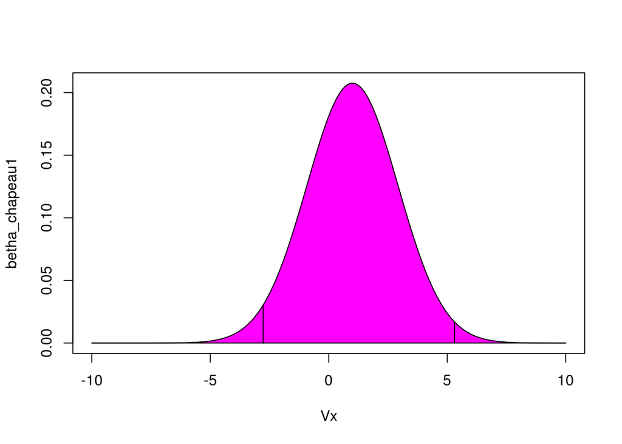

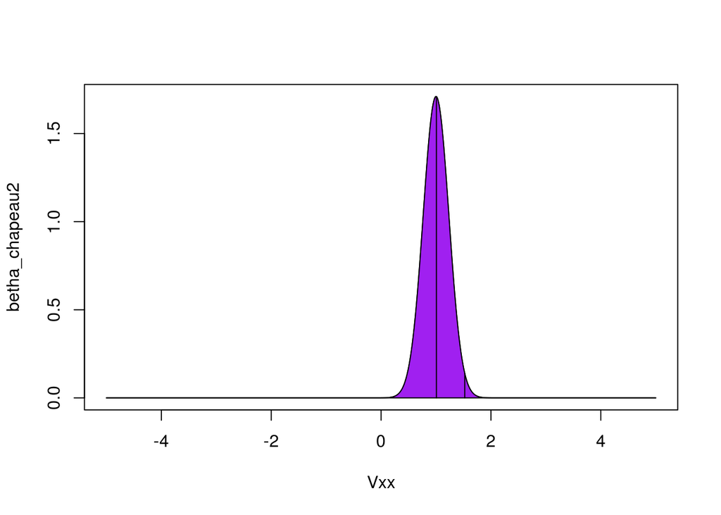

-On observe que $\hat{\beta_{1}}$ est de variance plus grande que $\hat{\beta_{2}}$, ce qui est cohérent avec le modèle défini dans l’énoncé, puisque les écarts type s’ajoutent pour X_{1} (X_{2} dépend de X_{1} avec un bruit gaussien).

-D’après la représentation des quantiles, on remarque que $\hat{\beta_{1}}$ comporte plus d’observations que $\hat{\beta_{2}}$, ce qui peut être expliqué par le même argument évoqué précédemment.

## Question e:

On dessine les ellipses des probabilités.

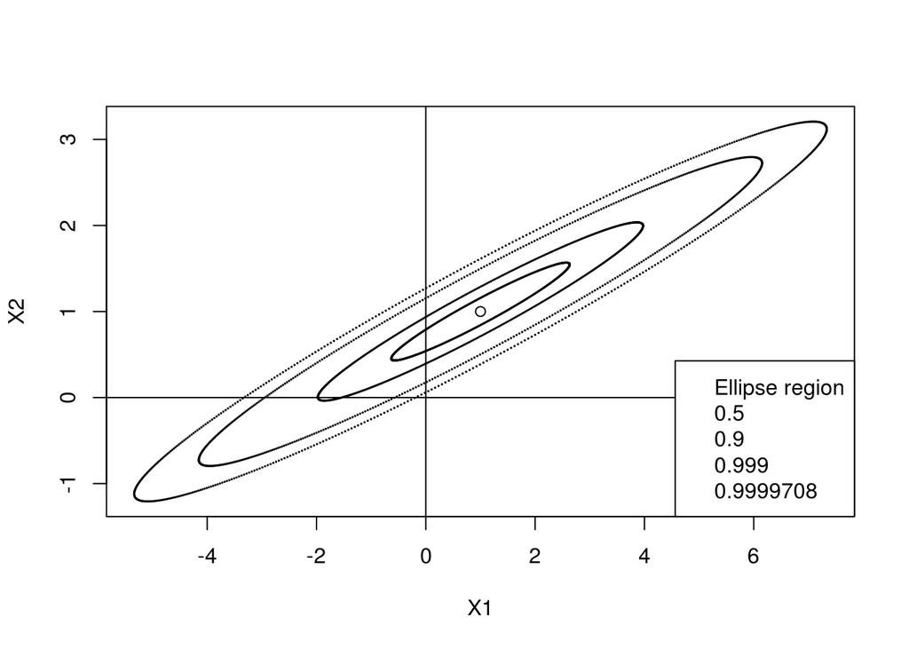

#### Commentaires:

On remarque que: 1) La taille des ellipses est proportionnelle positivement à la $\mathbb{P}(\hat\beta_1 \in ellipse; \hat\beta_2 \in ellipse)$.

2)La dépendance entre $X_1$ et $X_2$ influe la précision de l’estimation de $Y$, ce qui fait que pour $\mathbb{P}$ = $p-value$ , le point $(0,0)$ n’appartient pas à l’ellipse associé à cette pobabilité.

# MORALITE:

Dans le cas d’une estimation d’une variable par régression linéaire, faut retenir des régresseurs:

-qui sont les plus corrélées avec la variable à expliquer (But de la Question 1).

-qui son les moins corrélées entre elles (But de la question2).